# Lab 06 SGlasser

Sonja

13/10/2021

## Lab 06: Introduction to Inference

##### Worked with:

Aliza Fassler and Justin Roch

#### Learning objectives, technical skills and concepts:

- Sampling distribution: sample standard deviation vs standard error
- Building custom functions
- T-tests
- Resampling
- R formula notation
- R object structure

#### Q1

```r
rm(list = ls())

sse_mean = function(x)
    { na.x<-is.na(x)
          x2<- x[!na.x]
                 sd.x2=sd(x2)
                  n=length(x2)
        sd.x2/(sqrt(n))
      }

sse_mean(penguins$body_mass_g)
```

```
## [1] 43.36473
```

```r
sse_mean(mtcars$mpg)
```

```
## [1] 1.065424
```

#### Q2

```r
two_group_resample = function(x, n_1, n_2)
  {
    dat_1 = sample(x, n_1, replace = TRUE)
    dat_2 = sample(x, n_2, replace = TRUE)
      difference_in_means =
              mean(dat_1, na.rm = TRUE) - mean(dat_2, na.rm = TRUE)
 return(difference_in_means)
}

two_group_resample(dat_pen$flipper_length_mm, 68, 152)
```

```
## [1] -1.319128
```

#### Q3

The type of sampling executed in Q2 breaks apart the association of the value from the variable, so, we are performing a Monte Carlo resampling. It samples flipper length from all values regardless of which species the value is associated to. This would be simulating the null hypothesis which is that all flipper lengths come the a single population of flipper lengths that are normally distributed.

#### Q4

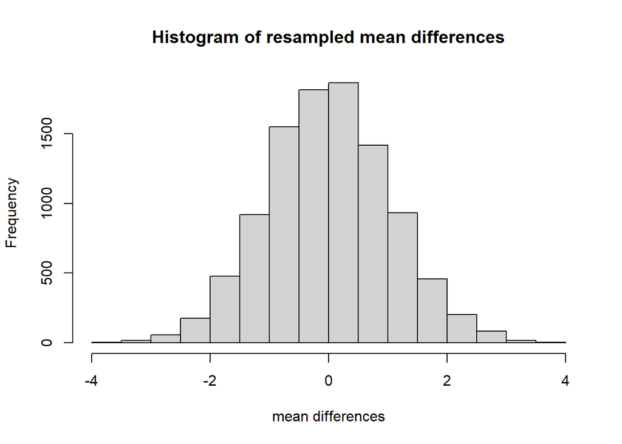

```r
n = 10000
mean_differences = c()
for (i in 1:n)
{
  mean_differences = c(
    mean_differences,
    two_group_resample(dat_pen$flipper_length_mm, 68, 152)
  )
}
hist(mean_differences, main="Histogram of resampled mean differences", xlab = "mean differences")
```

#### Q5

After completing 10,000 simulations none of the resampled differences were greater than 5.8, all fell within approxiamately -4 and 4.

```r
# code you used to check the number of differences greater than 5.8
sum(abs(mean_differences) >= diff_observed)
```

```
## [1] 0
```

#### Q6

I would have to run at least 10 million simulations in order to see a difference in mean flipper length equal to or greater than 5.8 mm.

#### Q7

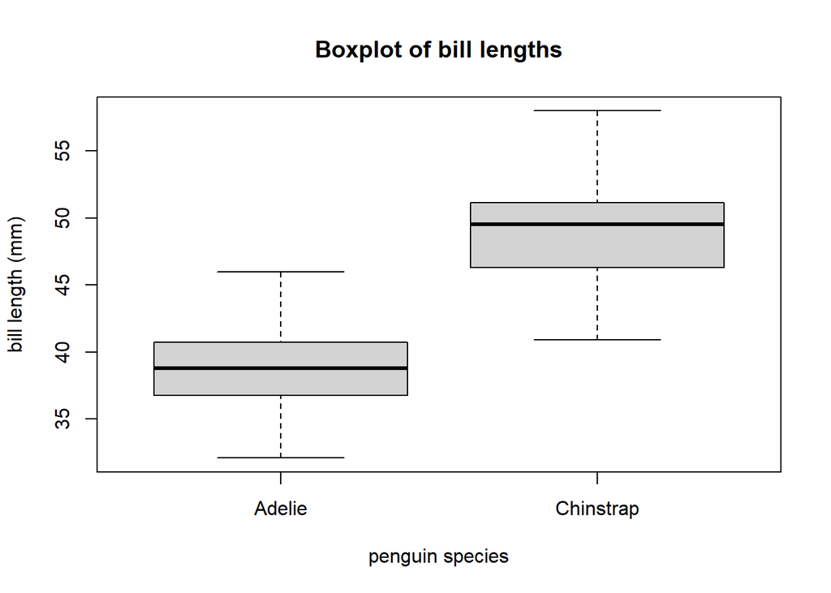

#### Q8

Group means of bill length of two species of penguins

```
##     species bill_length_mm
## 1    Adelie       38.79139
## 2 Chinstrap       48.83382
```

```r
diff_crit
```

```
## [1] 10.04243
```

#### Q9

By chance, it would be very very very very unlikely that we would find a difference of 10.04 mm in bill length as we have found from our t-test of the observed data if there was in fact no difference between bill length between the species.

```r
t_test = t.test(dat_pen$bill_length_mm ~ dat_pen$species)
t_test
```

```
##
##  Welch Two Sample t-test
##
## data:  dat_pen$bill_length_mm by dat_pen$species
## t = -21.865, df = 106.97, p-value < 2.2e-16
## alternative hypothesis: true difference in means is not equal to 0
## 95 percent confidence interval:
##  -10.952948  -9.131917
## sample estimates:
##    mean in group Adelie mean in group Chinstrap
##                38.79139                48.83382
```

```r
t_test$estimate
```

```
##    mean in group Adelie mean in group Chinstrap
##                38.79139                48.83382
```

#### Q10

There were 0 differences in the means greater than the diff_crit of 10.04.

```r
n = 1000
mean_differences = c()
for (i in 1:n)
{
  mean_differences = c(
    mean_differences,
    two_group_resample(dat_pen$bill_length_mm, 68, 152)
  )
}

sum(abs(mean_differences) >= diff_crit)
```

```
## [1] 0
```

#### Q11

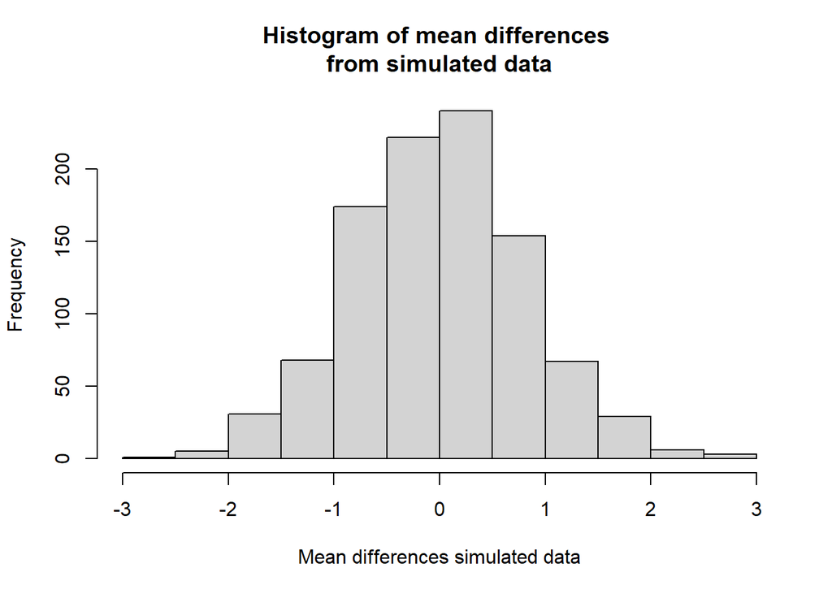